# Estudo de Caso 1

### Universidade Federal do Estado do Rio de Janeiro

### Prof: Steven Ross

### Alunas: Carla Ferreira da Costa, Leticia Mesquita Prata e Dayane

### 2017-10-16

### Introdução

Como muitos ramos que compõe a pesquisa, a estatística é uma das vertentes exploradas. Dessa forma, com o objetivo de buscar uma melhor analise do perfil da população que habita o Noroeste Fluminense do Estado do Rio de Janeiro foi elaborado um censo. Nele, foram coletadas informações que tem como referência cerca de 32.561 pessoas. Sendo assim, foram feitos questionamentos que relacionavam diversas áreas da individualidade de cada entrevistado. Essa análise, tem como objetivo final apresentar uma recomendação de política pública ao Ministro da Saúde em um evento sediado pela Fiocruz. De um modo esquemático, pode-se dizer que os dados pesquisados quando não relacionados possuem uma singularidade. Todavia, quando se têm um entrelaçar de todos os fatores através da estatística as respostas obtidas possuem uma melhor validação. Em um primeiro momento, o setor de pesquisa avaliou não só o IMC, mas também construiu um banco de dados. Com todos os resultados obtidos ao longo do projeto e o encaixe correto da das informações, a implantação de uma medida pública direcionada a essa parcela da população conseguiu ser vislumbrada.

### Metodologia

Para a construção do panorama embasado de uma política pública, foram utilizados dois programas: (1) Excel; (2) R com versão 32. O primeiro se mostrou necessário para planejar a base de dados e para fazer as tabelas. Diferente do segundo que permitiu a relação entre os resultados obtidos. As informações que constam no Excel foram utilizadas no programa R, com isso foi possível uma investigação mais abrangente da situação em que se encontra a população do Noroeste Fluminense. O software estatístico R apresenta a necessidade de obtenção de um comando para a importação de dados, assim como a aplicação de qualquer análise estatística. No presente caso, o programa de suporte utilizado foi o Excel. Além desse fator, o programa R possui uma grande quantidade de pacotes que foram selecionados para analisar os valores adquiridos ao longo da pesquisa. As informações constantes na Base de dados dizem respeito à idade, ocupação, salário, escolaridade, anos de estudo, situação conjugal, setor, raça, gênero, horas de trabalho na semana e a localidade. Todavia, para a realização de uma conclusão nem todos os dados que foram utilizados, uma vez que o raciocínio empregado dividiu todo o estudo em blocos. Dessa maneira, os gráficos foram divididos em três grandes blocos. Entretanto, a correlação com o IMC é o denominador comum em todos os três blocos. O primeiro bloco tem como objetivo identificar o perfil da população indicando o sexo e a idade. Com essa conclusão alcançada temos o primeiro direcionamento da política pública. O segundo bloco sustenta o primeiro, uma vez que a intenção dele é apontar a possibilidade da relação do IMC com a ausência ou a presença da escolaridade. É importante salientar que uma política pública vai além da saúde. Visto isso, o último bloco objetiva em que segmento do labor existe uma precariedade da saúde, direcionando ainda mais a medida implantada.

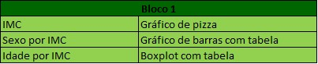

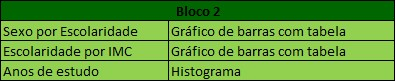

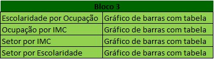

Foi elaborada também uma tabela de tabulação com todos os gráficos que feitos ao longo do processo da pesquisa. Embora exista a possibilidade de mais de um gráfico dependendo da variável avaliada, optamos sempre por aquele que tem uma maior facilidade na descrição.

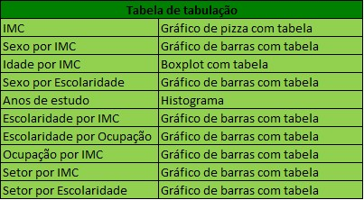

### Discussão

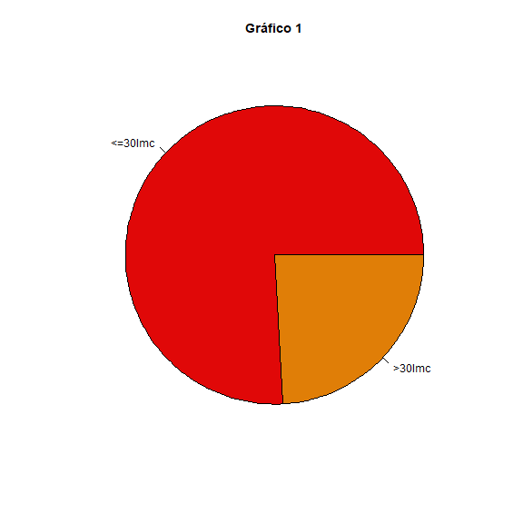

```r
> with(Dataset, pie(table(IMC), labels=levels(IMC), xlab="", ylab="",
+ main="Gráfico 1", col=c("#e00808","#e07e07")))
```

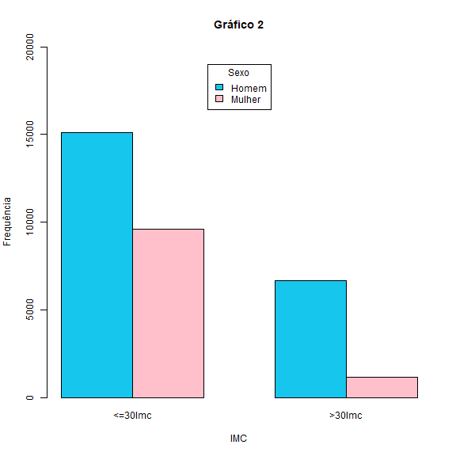

```r
> with(Dataset, Barplot(IMC, by=Sexo, style="parallel", legend.pos="top", xlab="IMC",
+   ylab="Frequência",ylim=c(0,20000), main="Gráfico 2", col=c("#17c6ed","pink")))
```

Outro fator incluso na pesquisa foi à idade. Nessa avaliação o gráfico Boxplot foi empregado. Nele, a relação da variável quantitativa continua e uma qualitativa pode ser feita. Com o Gráfico e a tabela 3 se dá de maneira correta, o mínimo, o primeiro quartil, a mediana, o terceiro quartil e o máximo. Com isso, quando o IMC > 30 o mínimo de idade de 19 anos. O primeiro quartil que representa 25% da população tem de 20 a 36 anos. A mediana que é utilizada com a presença de outlier corresponde à idade de 44 anos. Os outros 25%, terceiro quartil refletem indivíduos de 45 a 51 anos. Além disso, o último fator é o valor máximo, onde se encontra pessoas com 90 anos de idade. Nesse primeiro momento, já se torna possível à idealização de uma medida de saúde pública voltada a indivíduos que atingiram mais de 30 anos de idade e que são do sexo masculino.

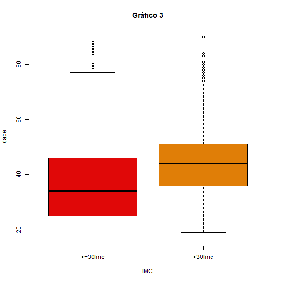

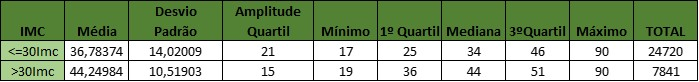

```r
> Boxplot(IDADE~IMC, data=Dataset, id.method="none", xlab="IMC", ylab="Idade",
+   main="Gráfico 3",col=c("#e00808","#e07e07"))
```

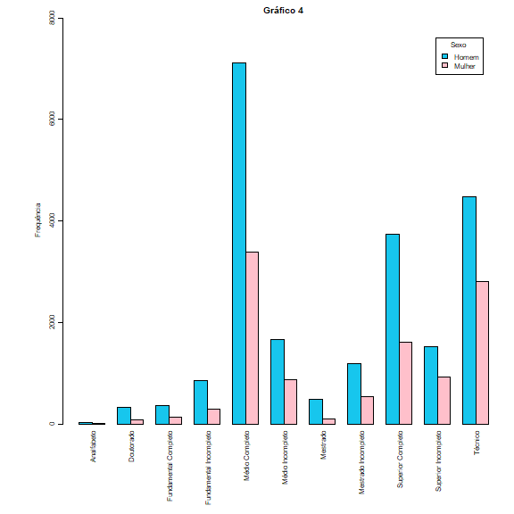

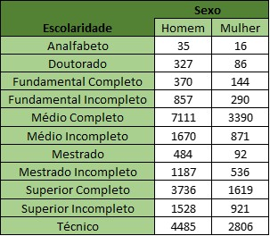

```r
> par(mar=c(10,7,2,1),mgp=c(2.4,0.8,0),cex=0.7)
> with(Dataset, Barplot(Escolaridade, by=Sexo, style="parallel", legend.pos="topright",
+   xlab="", ylab="Frequência", las=3, ylim=c(0,8000), main="Gráfico 4",
+   col=c("#17c6ed","pink")))
```

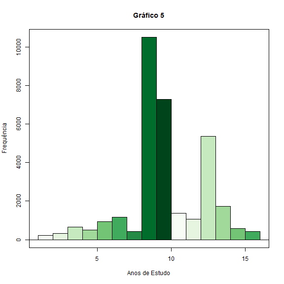

```r
> with(Dataset, Hist(Anos.de.estudo, scale="frequency", breaks="Sturges",
+   col=COR,xlab="Anos de Estudo", ylab="Frequência", main="Gráfico 5"))
```

```r
> library(RColorBrewer)
> COR<-brewer.pal(9,"Greens")
> require(RColorBrewer)
```

Dessa forma, para se chegar a maiores conclusões foi obtida a relação entre a escolaridade e o IMC no Gráfico e na tabela 6. Nela, pessoas que tem Ensino Superior Completo que estão na totalidade de 2.221 tem o Índice de Massa Corporal maior do que 30. O segundo grau de escolaridade que teve maior número foi o Ensino Médio Completo com 1.675 de indivíduos nele. Por sua vez, os Técnicos possuem 1.387 pessoas com o Índice acima de 30. Com a inter-relação dos gráficos obtidos até o atual momento é legitima a compreensão de uma medida inclinada a indivíduos que concluíram o Ensino superior em um primeiro olhar. Mas, não pode excluir aqueles que completaram o Ensino Médio e os que fizeram um curso Técnico.

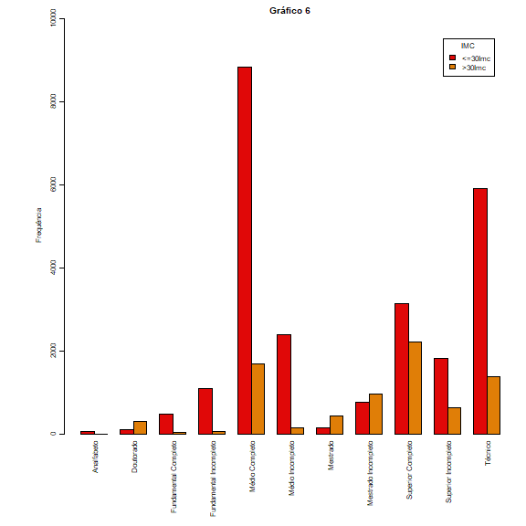

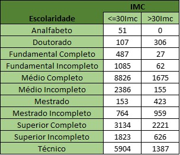

```r
> par(mar=c(10,7,2,1),mgp=c(2.4,0.8,0),cex=0.7)
> with(Dataset, Barplot(Escolaridade, by=IMC, style="parallel", legend.pos="topright",
+   xlab="", ylab="Frequência", las=3, ylim=c(0,10000), main="Gráfico 6", col=c("#e00808","#e07e07")))
```

Para se ter ideia da ocupação e do setor no qual ocorre uma maior incidência de pessoas com o IMC acima de 30, antes de tudo foi essencial entender a conexão com a Escolaridade. Primeiramente, foi elaborado o Gráfico e a tabela 7, onde se tem a Escolaridade pela Ocupação. Dessa forma, a medida pública vai ser encaminhar para uma determinada ocupação e posteriormente a um setor. É importante salientar que a medida será encaminhada para pessoas que possuem uma maior precariedade em um panorama geral, mas isso não significa que ela não será empregada a pessoas que não detém um IMC dentro da normalidade.

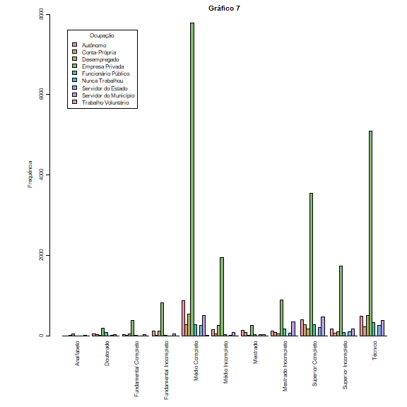

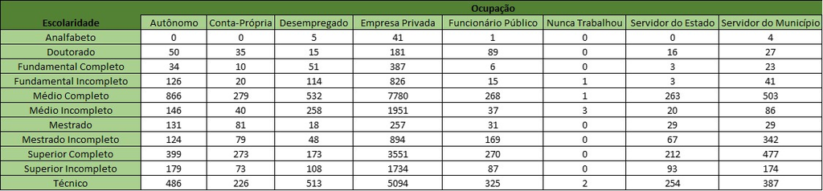

```r
> par(mar=c(10,7,2,1),mgp=c(2.4,0.8,0),cex=0.7)
> with(Dataset, Barplot(Escolaridade, by=Ocupação, style="parallel",
+   legend.pos="topleft", xlab="", ylab="Frequência", las=3, ylim=c(0,8000), main="Gráfico 7"))
```

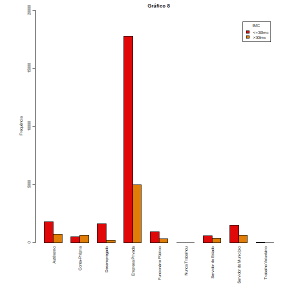

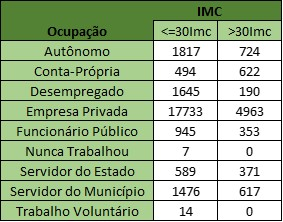

```r
> par(mar=c(9,7,2,1),mgp=c(2.4,0.8,0),cex=0.7)
> with(Dataset, Barplot(Ocupação, by=IMC, style="parallel", legend.pos="topright",
+   xlab="", ylab="Frequência",las=3, ylim=c(0,20000), main="Gráfico 8",
+   col=c("#e00808","#e07e07")))
```

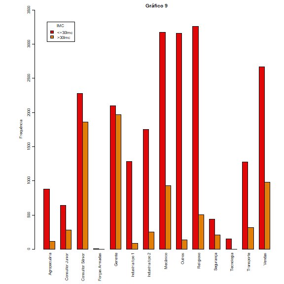

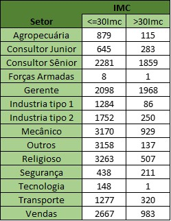

```r
> par(mar=c(7,7,2,1),mgp=c(2.4,0.8,0),cex=0.7)
> with(Dataset, Barplot(Setor, by=IMC, style="parallel", legend.pos="topleft", xlab="",
+   ylab="Frequência",las=3, ylim=c(0,3500), main="Gráfico 9",col=c("#e00808","#e07e07")))
```

Posteriormente, para se chegar a uma conclusão eficaz foi pensado no Gráfico com a tabela 10. Nela existe uma correlação da Escolaridade com o Setor. Dessa maneira, a intensificação da afirmação que os indivíduos que completaram o Ensino Superior e aqueles que tiveram a finalização do Ensino Médio têm o maior IMC pode ser identificada. Principalmente pelo fato de 1.369 pessoas que trabalham como gerente e 1.495 indivíduos que atuam como Consultor sênior tem o Ensino Superior Completo. Além desse fator, 1069 vendedores possuem Ensino Médio Completo.

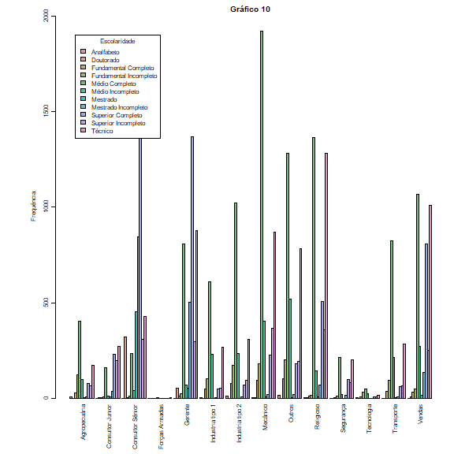

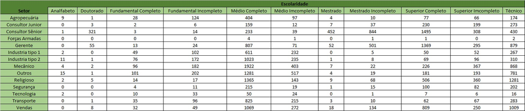

```r
> par(mar=c(7,7,2,1),mgp=c(2.4,0.8,0),cex=0.7)
> with(Dataset, Barplot(Setor, by=Escolaridade, style="parallel", legend.pos="topleft",
+   xlab="", ylab="Frequência", las=3, ylim=c(0,2000), main="Gráfico 10"))
```

### Resultado

Como se verifica na discussão os resultados obtidos tem um vínculo. Dessa maneira, um fator leva a outro. Com todos os 10 gráficos e as suas respectivas tabelas podemos perceber que a política pública de saúde estará voltada para a parcela masculina acima de 36 anos. Sendo assim, as medidas estão direcionadas para um público alvo. É importante salientar, que a partir dos trinta anos, o sistema metabólico do indivíduo começa a ser menos eficaz, uma vez que o envelhecimento retarda as reações que ocorrem no organismo. Pensando nesse viés, a conclusão concebida nesse primeiro momento com base nos resultados apresentados no primeiro bloco está relacionada com a atividade física. O sedentarismo é um fator encontrado principalmente a partir dessa idade, dessa forma a primeira medida que deve ser implantada é o incentivo a prática de exercícios físicos. Os resultados encontrados relacionados à escolaridade mostram que existe uma tendência do aumento do IMC para pessoas que tem o Ensino Médio Completo, o Ensino Superior Completo e também aqueles que têm um curso Técnico. Consequentemente, a medida tem que ir além do estimulo a atividade física. Ela tem que englobar o setor escolar, acadêmico e o nível técnico. Uma proposta que pode ser atribuída é a educação alimentar como matéria obrigatória em todos esses segmentos. Dessa maneira, o conhecimento perante a alimentação poderá ser empregado e aplicado na vida não só dessas pessoas, mas também por aqueles que possuem um IMC considerado fora da normalidade. Com isso afetará a parcela feminina da sociedade que possui essa característica. Outro fator que foi descoberto com a Base de Dados foi à ocupação. Nela, a empresa privada teve um maior número de trabalhadores. Mas, aqueles que possuem um trabalho autônomo e são servidores municipais tem grande ocorrência. Relacionando as ocupações que possuem um IMC considerado maior que 30 com o setor é possível detectar as áreas. Logo, os Gerentes, os Consultores Seniores e aqueles que trabalham em vendas são mencionados. A terceira medida de saúde pública é mais especifica a esse grupo de pessoas. Essa terceira proposta é de curto prazo, as outras duas citadas anteriormente são de longo prazo. A melhor estratégia se refere aos setores que são mais afetados. Eles terão a oportunidade de ter uma atenção especial. Sendo assim, o atendimento médico e principalmente nutricional será imposto a esses profissionais. Com essa proposta, os trabalhadores que estão em uma situação de risco para a saúde serão tratados com imediatismo.

### Considerações finais/Recomendações

As evidências encontradas tiveram um planejamento através da tabela de tabulação. Com ela foi possível uma estruturação de um pensamento crítico para as implementações de políticas públicas coerentes e possíveis de serem exercidas e apresentadas ao Ministro da Saúde no evento sediado pela Fiocruz. Além desse fator essencial, os gráficos utilizados tiveram o emprego de um conhecimento adquirido ao longo do tempo. Sendo assim, as variáveis quantitativas e qualitativas foram impostas de maneira corretas obtendo ao final resultados coerentes com a população do Noroeste do Estado do Rio de Janeiro.